# s04 — does disabling soft-clipping change SNP recovery? (chr19)

gwct

10/26/2026 13:03 EDT

```r
knitr::opts_chunk$set(echo = TRUE, warning = FALSE, message = FALSE, fig.align = "center")
library(ggplot2); library(dplyr); library(tidyr); library(readr); library(knitr)
source("analyses/lib/design.r")   # bartheme(), corecol(); knit from the project root
```

**Provenance**

- **Rendered from commit** `761a36dcb53d` (branch `mason2-sims`) on 2026-10-26 13:03
- **This notebook:** notebook as committed
- **Analysis code:** no uncommitted edits under `analyses/`
- Each data file’s producing script and command: the section’s `MANIFEST.yaml`

# 1 Question & design

**Does gatk’s high-divergence SNP loss come from soft-clipped bases being ignored?** A read that carries divergent bases toward its end is often soft-clipped there by the aligner; those bases stay in the BAM but a caller may or may not use them. One hypothesis for why gatk (HaplotypeCaller) recovers fewer divergent SNPs than bcftools/freebayes is that soft-clipping *starves* it of the alt allele. This section tests that hypothesis directly, and in isolation.

**The test is paired on a single BAM.** For each divergence we take the **existing s01 iter-1 gatk BAM** (SNP-only data, seed 42, 30×) and run HaplotypeCaller on it **twice**:

- `gatk_default` — HaplotypeCaller’s default, which **uses** soft-clipped bases.
- `gatk_nosoftclip` — the same command plus `--dont-use-soft-clipped-bases`, which **ignores** them.

Because both calls see the *identical* alignment (same reads, same clips, same mapping), any difference in recovery is attributable to the flag alone — nothing else changes. We score each call against the controlled truth with `analyses/lib/compare_vcfs.py` (match on POS/REF/ALT after `bcftools norm`), and read out SNP-divergence recall (`div_tp / n_truth_div`) and het recall (`het_tp / n_truth_het`). Driver: `analyses/s04-softclip/run_softclip_toggle.sh <DIV>`.

**Scope & assumptions.**

- Two divergences, **D ∈ {0.06, 0.10}** — the regime where gatk’s deficit is largest and where a clipping effect, if any, should be most visible. H = 0.005, 30×, iteration 1 only (single-shot; this is a caller-flag test, not an iteration test).
- Only **gatk** is toggled — it is the caller with the deficit; the flag is a HaplotypeCaller option.
- **Prediction** from the assembler-not-clipping account (see the s01/s02 read-fate sections: the SNPs gatk misses mostly *have the base present at their position* — they are assembler-limited, not alignment/clipping-limited): recall should **barely move**.

```r
res <- "analyses/s04-softclip/results/"
sc <- bind_rows(lapply(c("0.06", "0.10"), function(d)
        read_csv(paste0(res, "softclip-toggle-", d, ".csv"), col_types = cols()))) %>%
  mutate(mode = sub("gatk_", "", caller),                       # default | nosoftclip
         mode = factor(mode, levels = c("default", "nosoftclip")),
         div_recall = div_tp / n_truth_div,                     # SNP divergence recall
         het_recall = het_tp / n_truth_het)                     # SNP het recall
```

# 2 Result: disabling soft-clipping does not recover the missed SNPs

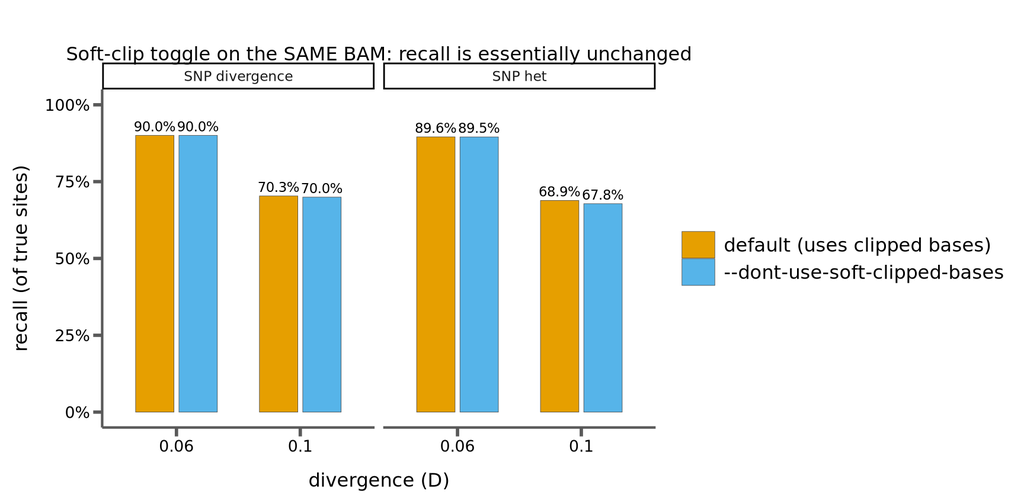

```r
sc %>%
  select(divergence, mode, `SNP divergence` = div_recall, `SNP het` = het_recall) %>%
  pivot_longer(c(`SNP divergence`, `SNP het`), names_to = "site", values_to = "recall") %>%
  ggplot(aes(factor(divergence), recall, fill = mode)) +
  geom_col(position = position_dodge(width = 0.7), width = 0.62, color = "grey30", linewidth = 0.15) +
  geom_text(aes(label = sprintf("%.1f%%", 100 * recall)),
            position = position_dodge(width = 0.7), vjust = -0.4, size = 3) +
  facet_wrap(~ site) +
  scale_fill_manual(values = corecol(pal = "wilke", numcol = 2),
                    labels = c("default (uses clipped bases)", "--dont-use-soft-clipped-bases"),
                    name = "HaplotypeCaller") +
  scale_y_continuous(labels = scales::percent, limits = c(0, 1)) +
  labs(x = "divergence (D)", y = "recall (of true sites)",
       title = "Soft-clip toggle on the SAME BAM: recall is essentially unchanged") +
  bartheme()
```

The bars are visually indistinguishable. The change from *disabling* soft-clipped bases, in the paired counts, is:

```r
sc %>%
  group_by(divergence) %>%
  summarize(
    `div recall default`    = sprintf("%.2f%%", 100 * div_recall[mode == "default"]),
    `div recall nosoftclip` = sprintf("%.2f%%", 100 * div_recall[mode == "nosoftclip"]),
    `Δ div_tp (sites)`      = div_tp[mode == "nosoftclip"] - div_tp[mode == "default"],
    `het recall default`    = sprintf("%.2f%%", 100 * het_recall[mode == "default"]),
    `Δ het_tp (sites)`      = het_tp[mode == "nosoftclip"] - het_tp[mode == "default"],
    `Δ false positives`     = fp[mode == "nosoftclip"] - fp[mode == "default"],
    .groups = "drop") %>%
  kable(caption = "Effect of --dont-use-soft-clipped-bases (nosoftclip − default). Negative Δ = disabling clipped bases HURTS.",
        table.attr = 'class="center"', format.args = list(big.mark = ","))
```

Effect of –dont-use-soft-clipped-bases (nosoftclip − default). Negative Δ = disabling clipped bases HURTS.

| divergence | div recall default | div recall nosoftclip | Δ div_tp (sites) | het recall default | Δ het_tp (sites) | Δ false positives |
| --- | --- | --- | --- | --- | --- | --- |
| 0.06 | 90.04% | 90.04% | 107 | 89.56% | -64 | 26 |
| 0.10 | 70.34% | 69.96% | -23,464 | 68.88% | -3,236 | -2,846 |

**Interpretation.** Ignoring soft-clipped bases does **not** rescue the SNPs gatk misses — it moves recall by a fraction of a percent, and in the wrong direction:

- **D = 0.06:** div recall 90.04% → 90.04% (Δ = +107 sites, +0.003%). No effect.
- **D = 0.10:** div recall 70.34% → **69.96%** (Δ = −23,464 sites, −0.5% relative). Disabling clipped bases *slightly lowers* recall, and het recall likewise (68.9% → 67.8%). The one thing that improves is false positives (fewer, because fewer bases means fewer calls).

If soft-clipping were starving the caller of the alt allele, removing the (already-used) clipped bases could only make things worse, and *using* them should be what helps — which is exactly the sign we see, but the magnitude is tiny. The decisive point is the **null**: the ~30% of divergent SNPs gatk fails to recover at D = 0.10 are **not** hiding in soft-clipped bases. Toggling how the caller treats those bases recovers essentially none of them. This is a fourth independent line — alongside the caller-swap (bcftools/freebayes recover gatk’s misses from the same BAMs), the caller-independent read classification, and the per-variant read-fate result (gatk’s not-called SNPs mostly have the base already aligned at their position) — that gatk’s high-divergence deficit is its **reference-anchored local reassembler failing on divergent sequence**, not soft-clipping upstream.

# 3 Does it hold across iterations?

The test above is iteration 1 — deliberately, because that is where soft-clipping is **maximal**: the reads are mapped against the raw reference at full divergence. As iteration proceeds the consensus converges toward the sample, the effective divergence to the mapping target drops, and soft-clipping falls with it (the read-fate sections show gatk’s called-SNP clipping collapsing across iterations). So iter 1 is the strongest possible test — but we confirm the toggle stays inert once clipping has mostly disappeared.

**How iter ≥ 2 is scored.** At iteration *k* the gatk BAM is mapped to `consensus_{k-1}`, so we call HaplotypeCaller against that consensus (default vs `--dont-use-soft-clipped-bases`) and score the **cumulative recovered set** the way the s01 pipeline defines it: `recovered_k` = the set already baked into `consensus_{k-1}` (identical for both arms) **∪** the new hom-alt SNP calls. Only iter-*k* calling is toggled, so any difference is the flag alone. (s01 is SNP-only, so the consensus keeps reference coordinates — no liftover. Driver: `run_softclip_toggle_iter.sh <DIV> <ITER>`.)

```r
iters <- c(1, 2, 3)
sweep <- bind_rows(lapply(c("0.06", "0.10"), function(d)
  bind_rows(lapply(iters, function(k) {
    f <- if (k == 1) paste0(res, "softclip-toggle-", d, ".csv")
         else        paste0(res, "softclip-toggle-", d, "-iter", k, ".csv")
    read_csv(f, col_types = cols())                       # fails loudly if a run is missing
  })))) %>%
  mutate(mode = factor(sub("gatk_", "", caller), levels = c("default", "nosoftclip")),
         div_recall = div_tp / n_truth_div)
```

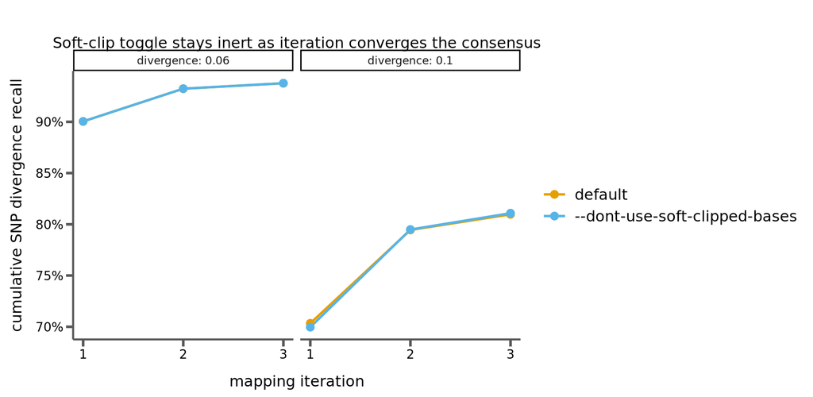

```r
ggplot(sweep, aes(iteration, div_recall, color = mode, group = mode)) +
  geom_line(linewidth = 0.9) + geom_point(size = 2.6) +
  facet_wrap(~ divergence, labeller = label_both) +
  scale_color_manual(values = corecol(pal = "wilke", numcol = 2),
                     labels = c("default", "--dont-use-soft-clipped-bases"), name = "HaplotypeCaller") +
  scale_x_continuous(breaks = iters) + scale_y_continuous(labels = scales::percent) +
  labs(x = "mapping iteration", y = "cumulative SNP divergence recall",
       title = "Soft-clip toggle stays inert as iteration converges the consensus") +
  bartheme()
```

```r
sweep %>% group_by(divergence, iteration) %>%
  summarize(`div recall default`    = sprintf("%.2f%%", 100 * div_recall[mode == "default"]),
            `div recall nosoftclip` = sprintf("%.2f%%", 100 * div_recall[mode == "nosoftclip"]),
            `Δ div_tp (sites)`      = div_tp[mode == "nosoftclip"] - div_tp[mode == "default"],
            .groups = "drop") %>%
  kable(caption = "Soft-clip toggle effect on cumulative div recall, by iteration (nosoftclip − default).",
        table.attr = 'class="center"', format.args = list(big.mark = ","))
```

Soft-clip toggle effect on cumulative div recall, by iteration (nosoftclip − default).

| divergence | iteration | div recall default | div recall nosoftclip | Δ div_tp (sites) |
| --- | --- | --- | --- | --- |
| 0.06 | 1 | 90.04% | 90.04% | 107 |
| 0.06 | 2 | 93.24% | 93.24% | 131 |
| 0.06 | 3 | 93.77% | 93.77% | 188 |
| 0.10 | 1 | 70.34% | 69.96% | -23,464 |
| 0.10 | 2 | 79.45% | 79.49% | 2,838 |
| 0.10 | 3 | 80.97% | 81.09% | 7,232 |

**Interpretation.** Iteration lifts recall enormously (D=0.10: 70% → 81% — the point of the whole project), while the soft-clip toggle stays within **±0.5% at every iteration**. Its effect is not just small but *inconsistent in sign*: at D=0.10 disabling clipped bases costs 23k sites single-shot (−0.38% of truth), then flips to a negligible +2.8k / +7.2k (+0.05% / +0.12%) at iterations 2–3, and at D=0.06 it is a trivial positive throughout. That is the opposite of what a real clipping limitation would look like — a consistent, sizable gain from *using* the clipped bases. A sign-flipping, noise-level wobble is what you see when the flag simply doesn’t matter. The conclusion is iteration-independent: soft-clipping is not what limits gatk’s divergent-SNP recovery, single-shot or iterated; iteration, not the caller’s clip policy, is the lever that moves recall.

# 4 The toggle is gatk-specific: bcftools and freebayes

`--dont-use-soft-clipped-bases` is a **HaplotypeCaller option**, and there is no equivalent to run for the other two callers — not by omission, but by construction:

- **bcftools** `mpileup` builds its pileup from the *aligned* portion of each read; soft-clipped bases (CIGAR `S`) are simply not in the pileup. bcftools is therefore *already* in the “don’t use soft-clipped bases” regime, always.
- **freebayes** assembles haplotypes from the aligned reads and likewise does not use soft-clipped sequence; it exposes no soft-clip toggle.

So there is nothing to toggle — and the existing evidence already settles the question for them. In the caller-swap result, bcftools and freebayes (which *never* use soft-clipped bases) recover ~99 % of the divergent SNPs gatk misses **from the same BAMs**. If ignoring soft-clipped bases were a recovery handicap, the callers that always ignore them could not be the ones that recover *more*. Where bcftools/freebayes *do* miss SNPs, the per-variant read-fate analysis shows the cause is **alignment**: the read is clipped *off* the site or mapped elsewhere, so the alt base isn’t present at the position at all. That is an upstream *mapping* loss — the divergent bases were clipped away during alignment and aren’t reliably placed at the site — not a caller policy of ignoring bases that are present. No soft-clip flag, on any caller, recovers a base that alignment removed. This is why iteration (which re-anchors those reads) is the lever that helps the pileup/haplotype callers, exactly as the read-fate sections show.

# 5 Summary

- Re-calling the *same* iter-1 BAM with vs without `--dont-use-soft-clipped-bases` changes SNP divergence recall by **+0.003% (D=0.06)** and **−0.5% (D=0.10)** — i.e. not at all, or slightly worse.
- The same holds at **iterations 2 and 3**: the toggle’s effect stays a fraction of a percent as the consensus converges and clipping falls, so the conclusion is iteration-independent.
- The flag is **gatk-specific**; bcftools and freebayes never use soft-clipped bases yet recover most of what gatk misses, so “not using clipped bases” is not a recovery handicap. Their residual misses are alignment-limited (base clipped-off / mismapped), upstream of any caller flag.
- Soft-clipping is therefore **not** the mechanism behind gatk’s high-divergence SNP loss; the deficit is caller-side (assembler), consistent with the s01/s02 read-fate analyses.
- Practical takeaway: `--dont-use-soft-clipped-bases` is not a useful lever for recovering divergent SNPs here (it trades a sliver of recall for slightly fewer false positives).

## 5.1 Data dictionary

`analyses/s04-softclip/results/softclip-toggle-<D>.csv` — two rows per file (`gatk_default`, `gatk_nosoftclip`), one `compare_vcfs.py` summary each, scored on the *same* BAM. Columns (SNP subset used here; indel columns are all zero because this is SNP-only s01 data):

| column | meaning |
| --- | --- |
| `region, coverage, divergence, heterozygosity, seed` | simulation condition (chr19, 30×, D, H=0.005, seed 42) |
| `caller` | `gatk_default` or `gatk_nosoftclip` (the toggle) |
| `iteration` | mapping iteration (1 = single-shot) |
| `n_truth_div` | number of true SNP divergence (1\|1) sites |
| `div_tp` | divergence sites called hom-alt with matching allele (**recovered**) |
| `div_het` | divergence sites called heterozygous |
| `div_ref_or_absent` | divergence sites called hom-ref **or not called** — reference bias / loss |
| `div_other` | divergence hom-alt wrong allele / edge case |
| `n_truth_het` | number of true SNP het (0\|1) sites |
| `het_tp` | het sites called heterozygous (**recovered**) |
| `het_hom_alt` / `het_ref_or_absent` / `het_other` | het site miscall outcomes |
| `fp` | called SNP variants matching no truth site (**false positives**) |
| `n_called_snp` | total confident SNP calls |
| `n_truth_indel_*`, `indel_*`, `fp_indel`, `n_called_indel` | indel counterparts (all 0 here) |

Derived in this notebook: `div_recall = div_tp / n_truth_div`, `het_recall = het_tp / n_truth_het`, `mode` = the toggle parsed from `caller`.